# Complete Analysis Gallery - All jjstatsplot Functions

ClinicoPath Development Team

2025-06-30

# 1 Complete jjstatsplot Analysis Gallery

This comprehensive guide demonstrates every analysis type available in jjstatsplot with practical examples, use cases, and statistical interpretations.

```r
library(ClinicoPath)
library(dplyr)

# Load datasets
data(mtcars)
data(iris)

# Prepare example datasets
mtcars_clean <- mtcars %>%
  mutate(
    cyl = factor(cyl, labels = c("4-cyl", "6-cyl", "8-cyl")),
    am = factor(am, labels = c("Automatic", "Manual")),
    vs = factor(vs, labels = c("V-shaped", "Straight"))
  )

iris_clean <- iris %>%
  mutate(Species = factor(Species))
```

## 1.1 1. Histogram Analysis - `jjhistostats()`

### 1.1.1 Purpose

Explore the distribution of continuous variables with automatic normality testing and descriptive statistics.

### 1.1.2 When to Use

- Examine variable distributions before analysis
- Check normality assumptions
- Identify outliers and skewness
- Compare distributions across groups

### 1.1.3 Basic Usage

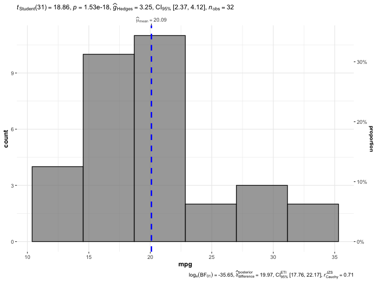

```r
# Single variable distribution
hist_basic <- jjhistostats(
  data = mtcars_clean,
  dep = "mpg",
  grvar = NULL  # No grouping variable
)

hist_basic$plot
```

### 1.1.4 Advanced: Multiple Variables

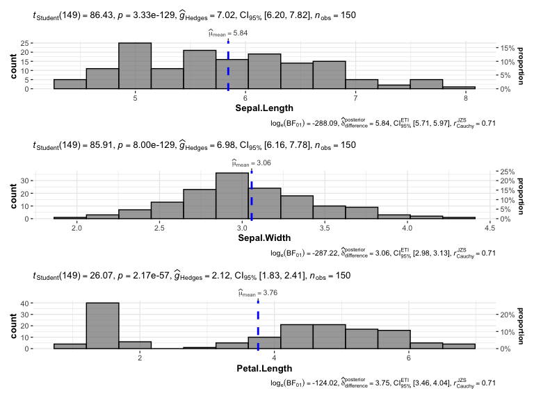

```r
# Multiple variables
hist_multi <- jjhistostats(
  data = iris,
  dep = c("Sepal.Length", "Sepal.Width", "Petal.Length"),
  grvar = NULL  # No grouping variable
)

hist_multi$plot
```

### 1.1.5 Grouped Analysis

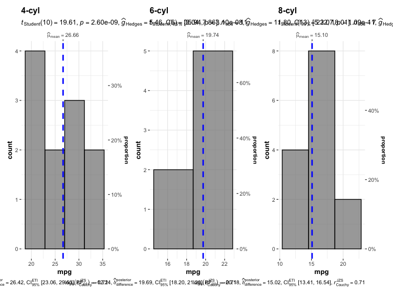

```r
# Separate histograms by group
hist_grouped <- jjhistostats(
  data = mtcars_clean,
  dep = "mpg",
  grvar = "cyl"
)

hist_grouped$plot2
```

### 1.1.7 Interpretation Tips

- **Normal distribution**: p > 0.05 in normality test
- **Skewness**: Asymmetric distribution patterns
- **Outliers**: Points far from main distribution

## 1.2 2. Scatter Plots - `jjscatterstats()`

### 1.2.1 Purpose

Examine relationships between two continuous variables with correlation analysis and regression fitting.

### 1.2.2 When to Use

- Explore bivariate relationships
- Test correlation hypotheses
- Visualize regression relationships
- Identify influential points

### 1.2.3 Basic Usage

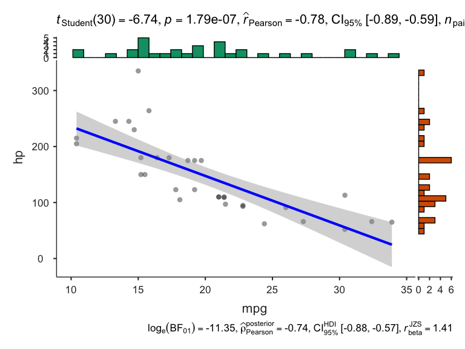

```r
# Basic scatter plot with correlation
scatter_basic <- jjscatterstats(
  data = mtcars_clean,
  dep = "mpg",
  group = "hp",
  grvar = NULL  # No grouping variable
)

scatter_basic$plot
```

### 1.2.4 Grouped Analysis

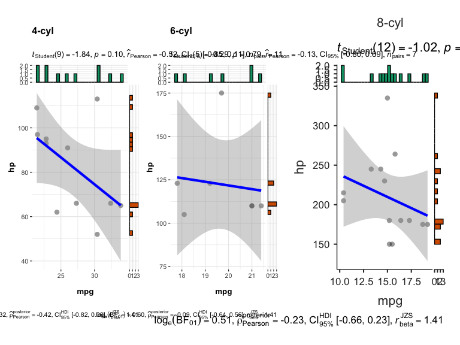

```r
# Separate scatter plots by group
scatter_grouped <- jjscatterstats(
  data = mtcars_clean,
  dep = "mpg",
  group = "hp",
  grvar = "cyl"
)

scatter_grouped$plot2
```

### 1.2.5 Statistical Output

- Pearson/Spearman correlation coefficient
- Confidence intervals
- Regression equation
- R-squared value

### 1.2.6 Interpretation Tips

- **Strong correlation**: |r| > 0.7
- **Moderate correlation**: 0.3 < |r| < 0.7
- **Weak correlation**: |r| < 0.3
- **Linear relationship**: Points follow straight line pattern

## 1.3 3. Box-Violin Plots (Between Groups) - `jjbetweenstats()`

### 1.3.1 Purpose

Compare continuous variables across independent groups with appropriate statistical tests.

### 1.3.2 When to Use

- Compare means/medians between groups
- Test group differences
- Visualize data distribution by group
- Assess homogeneity of variance

### 1.3.3 Basic Usage

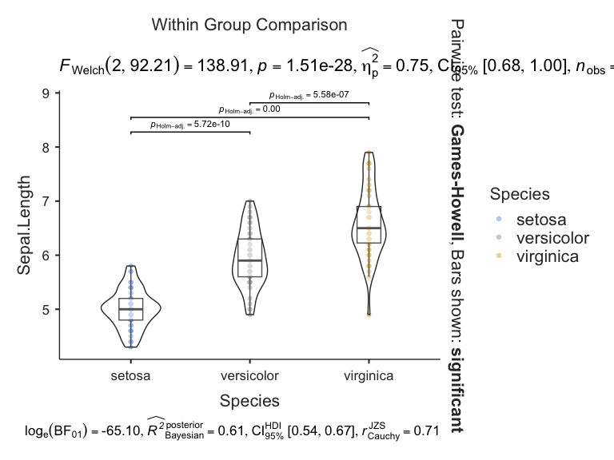

```r
# Compare groups
between_basic <- jjbetweenstats(
  data = iris_clean,
  dep = "Sepal.Length",
  group = "Species"
)

between_basic$plot
```

### 1.3.4 Multiple Dependent Variables

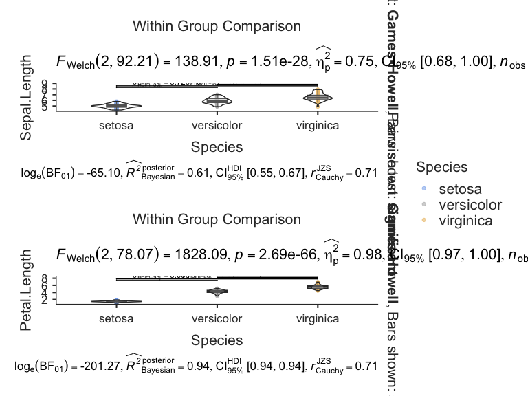

```r
# Multiple variables comparison
between_multi <- jjbetweenstats(
  data = iris_clean,
  dep = c("Sepal.Length", "Petal.Length"),
  group = "Species"
)

between_multi$plot
```

### 1.3.5 Statistical Output

- ANOVA or Kruskal-Wallis test
- Post-hoc pairwise comparisons
- Effect size measures (eta-squared, Cohen’s d)
- Homogeneity of variance tests

### 1.3.6 Interpretation Tips

- **Significant difference**: p < 0.05
- **Large effect**: η² > 0.14 or d > 0.8
- **Medium effect**: η² > 0.06 or d > 0.5
- **Small effect**: η² > 0.01 or d > 0.2

## 1.4 4. Correlation Matrix - `jjcorrmat()`

### 1.4.1 Purpose

Visualize correlations among multiple continuous variables simultaneously.

### 1.4.2 When to Use

- Explore multivariate relationships
- Identify redundant variables
- Screen variables for analysis
- Data reduction decisions

### 1.4.3 Basic Usage

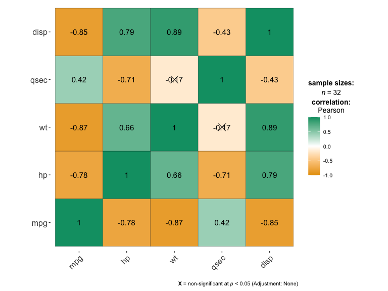

```r
# Correlation matrix
corrmat_basic <- jjcorrmat(
  data = mtcars,
  dep = c("mpg", "hp", "wt", "qsec", "disp"),
  grvar = NULL  # No grouping variable
)

corrmat_basic$plot
```

### 1.4.4 Grouped Analysis

[figure not shown]

```r
# Separate correlation matrices by group
corrmat_grouped <- jjcorrmat(
  data = iris,
  dep = c("Sepal.Length", "Sepal.Width", "Petal.Length", "Petal.Width"),
  grvar = "Species"
)

corrmat_grouped$plot2
```

### 1.4.5 Statistical Output

- Correlation coefficients matrix
- Significance testing for each correlation
- Confidence intervals

## 1.5 5. Dot Charts - `jjdotplotstats()`

### 1.5.1 Purpose

Display group means with confidence intervals and statistical comparisons.

### 1.5.2 When to Use

- Present group means clearly
- Show uncertainty (confidence intervals)
- Compare multiple groups
- Publication-ready group comparisons

### 1.5.3 Basic Usage

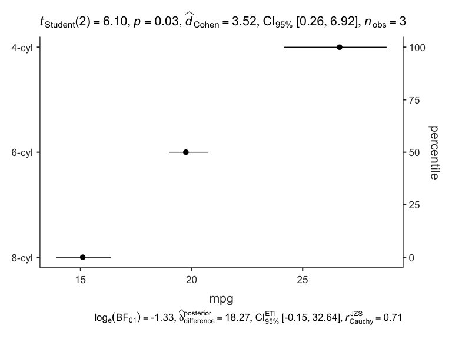

```r
# Dot chart with group means
dot_basic <- jjdotplotstats(
  data = mtcars_clean,
  dep = "mpg",
  group = "cyl",
  grvar = NULL  # No grouping variable
)

dot_basic$plot
```

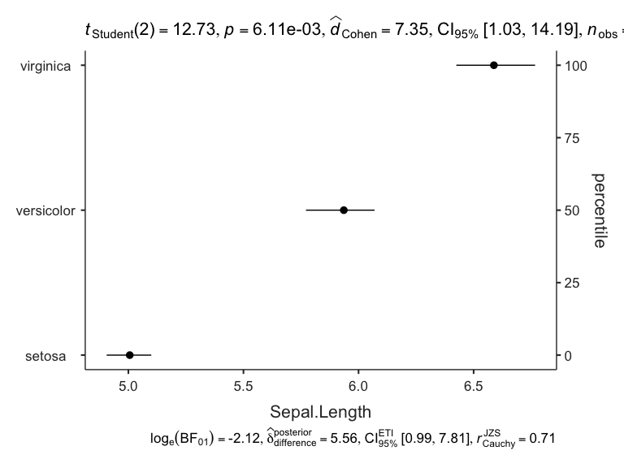

```r
# Multiple dependent variables
dot_multi <- jjdotplotstats(
  data = iris_clean,
  dep = c("Sepal.Length"),
  group = "Species",
  grvar = NULL  # No grouping variable
)

dot_multi$plot
```

### 1.5.5 Statistical Output

- Group means and standard errors
- Confidence intervals
- Statistical test results
- Effect sizes

### 1.5.6 Interpretation Tips

- **Non-overlapping CIs**: Likely significant difference
- **Large separation**: Meaningful group differences
- **Consistent patterns**: Across multiple variables

## 1.6 6. Bar Charts - `jjbarstats()`

### 1.6.1 Purpose

Analyze categorical variables and their associations with frequency tests.

### 1.6.2 When to Use

- Display frequency distributions
- Test independence between categorical variables
- Visualize contingency tables
- Report categorical data summaries

### 1.6.3 Basic Usage

```r
# Frequency bar chart
bar_basic <- jjbarstats(
  data = mtcars_clean,
  dep = "cyl",
  group = NULL,  # No grouping variable
  grvar = NULL  # No grouping variable
)

bar_basic$plot
```

[output not shown]

### 1.6.4 Two-Way Analysis

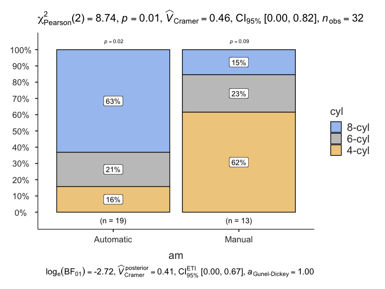

```r
# Two categorical variables
bar_twoway <- jjbarstats(
  data = mtcars_clean,
  dep = "cyl",
  group = "am",
  grvar = NULL  # No additional grouping variable
)

bar_twoway$plot
```

### 1.6.5 Statistical Output

- Chi-square test of independence
- Cramér’s V (effect size)
- Expected vs observed frequencies
- Standardized residuals

### 1.6.6 Interpretation Tips

- **Significant association**: p < 0.05 in chi-square test
- **Strong association**: Cramér’s V > 0.5
- **Moderate association**: Cramér’s V > 0.3
- **Weak association**: Cramér’s V > 0.1

## 1.7 7. Pie Charts - `jjpiestats()`

### 1.7.1 Purpose

Display proportional data with statistical testing for categorical variables.

### 1.7.2 When to Use

- Show proportions of categories
- Test goodness-of-fit
- Display survey results
- Present percentage distributions

### 1.7.3 Basic Usage

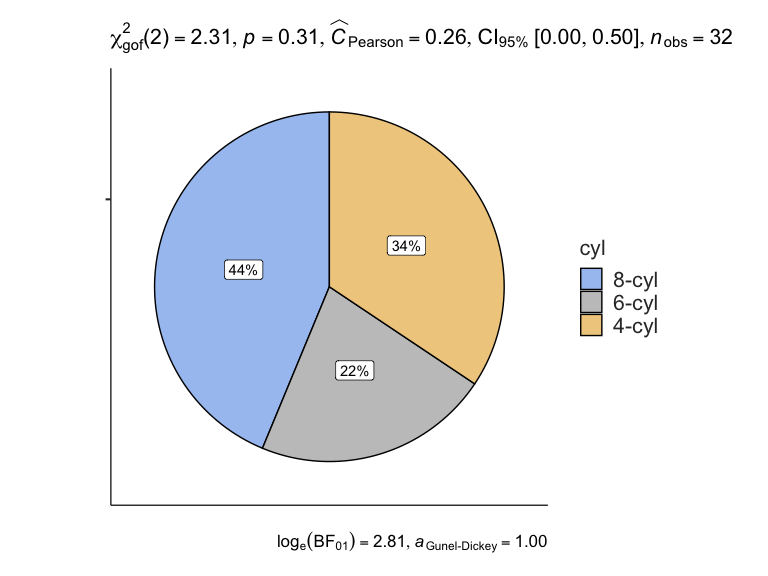

```r
# Basic pie chart
pie_basic <- jjpiestats(
  data = mtcars_clean,
  dep = "cyl",
  group = NULL,  # No grouping variable
  grvar = NULL  # No grouping variable
)

pie_basic$plot1
```

### 1.7.4 Grouped Analysis

```r
# Separate pie charts by group
pie_grouped <- jjpiestats(
  data = mtcars_clean,
  dep = "cyl",
  group = NULL,  # No grouping variable
  grvar = "am"
)

pie_grouped$plot2
```

[output not shown]

### 1.7.5 Statistical Output

- Goodness-of-fit tests
- Frequency and percentage tables
- Chi-square statistics

### 1.7.6 Interpretation Tips

- **Equal proportions**: Uniform distribution
- **Dominant category**: One slice much larger
- **Balanced distribution**: Similar slice sizes

## 1.8 8. Within-Subjects Analysis - `jjwithinstats()`

### 1.8.1 Purpose

Compare repeated measures or matched observations with appropriate paired tests.

### 1.8.2 When to Use

- Pre-post comparisons
- Repeated measures designs
- Matched pairs analysis
- Longitudinal data

### 1.8.3 Example with Paired Data

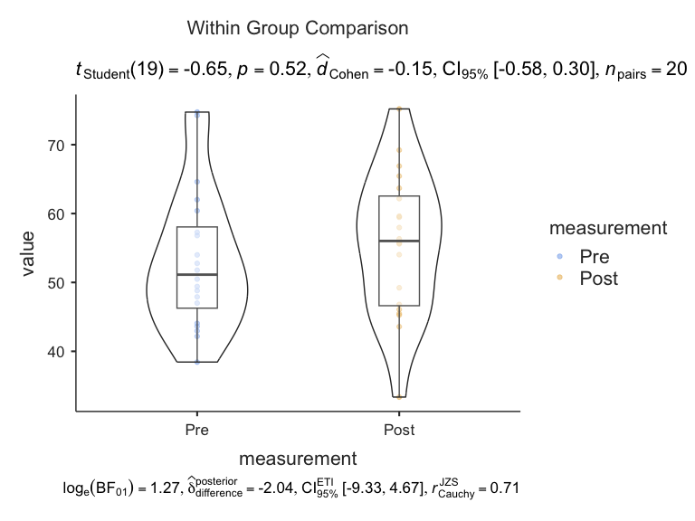

```r
# Create example paired data
paired_data <- data.frame(
  Subject = rep(1:20, 2),
  Time = rep(c("Pre", "Post"), each = 20),
  Score = c(rnorm(20, 50, 10), rnorm(20, 55, 10)),
  Group = rep(c("Treatment", "Control"), 20)
)

# Reshape for within-subjects analysis
paired_wide <- paired_data %>%
  tidyr::pivot_wider(names_from = Time, values_from = Score)

within_basic <- jjwithinstats(
  data = paired_wide,
  dep1 = "Pre",
  dep2 = "Post",
  dep3 = NULL,  # No third dependent variable
  dep4 = NULL,  # No fourth dependent variable
  )

within_basic$plot
```

### 1.8.4 Statistical Output

- Paired t-test or Wilcoxon signed-rank test
- Effect size (Cohen’s d for paired data)
- Confidence intervals for differences

### 1.8.5 Interpretation Tips

- **Significant change**: p < 0.05
- **Practical significance**: Consider effect size magnitude
- **Direction of change**: Positive vs negative differences

## 1.9 9. Waffle Charts - `jwaffle()`

### 1.9.1 Purpose

Display proportional data using a grid of squares for intuitive visualization.

### 1.9.2 When to Use

- Show parts of a whole
- Display survey results
- Present demographic breakdowns
- Alternative to pie charts

### 1.9.3 Basic Usage

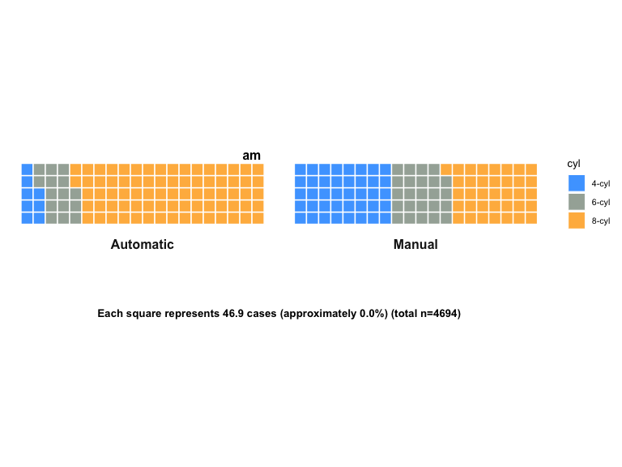

```r
# Waffle chart
waffle_basic <- jwaffle(
  data = mtcars_clean,
  counts = "hp",
  groups = "cyl",
  facet = "am"
)

waffle_basic$plot
```

### 1.9.4 Interpretation Tips

- **Visual proportion**: Each square represents equal units
- **Easy comparison**: Squares easier to compare than pie slices
- **Pattern recognition**: Spatial arrangement shows patterns

## 1.10 Choosing the Right Analysis

### 1.10.1 Decision Tree

```r
# Pseudocode decision tree
if (data_type == "one_continuous") {
  use_jjhistostats()
} else if (data_type == "two_continuous") {
  use_jjscatterstats() # or jjcorrmat() for multiple variables
} else if (data_type == "continuous_by_groups") {
  if (groups_independent) {
    use_jjbetweenstats()
  } else {
    use_jjwithinstats()
  }
} else if (data_type == "categorical") {
  if (display_preference == "bars") {
    use_jjbarstats()
  } else if (display_preference == "pie") {
    use_jjpiestats()
  } else if (display_preference == "waffle") {
    use_waffle()
  }
} else if (data_type == "group_means") {
  use_jjdotplotstats()
}
```

### 1.10.2 Data Type Requirements

| Analysis | Dependent Variable | Grouping Variable | Sample Size |
| --- | --- | --- | --- |
| Histogram | Continuous | Optional categorical | n >= 10 |
| Scatter | 2 × Continuous | Optional categorical | n >= 10 |
| Box-Violin | Continuous | Categorical (2+ levels) | n >= 5 per group |
| Correlation Matrix | 2+ × Continuous | Optional categorical | n >= 10 |
| Dot Chart | Continuous | Categorical (2+ levels) | n >= 3 per group |
| Bar Chart | Categorical | Optional categorical | n >= 5 |
| Pie Chart | Categorical | Optional categorical | n >= 5 |
| Within-Subjects | 2+ × Continuous | Optional categorical | n >= 5 pairs |
| Waffle Chart | Categorical | Optional categorical | n >= 10 |

## 1.11 Best Practices Summary

### 1.11.1 Statistical Considerations

1. **Check assumptions** before interpreting results
2. **Report effect sizes** alongside p-values
3. **Consider multiple comparisons** when doing many tests
4. **Validate findings** with appropriate diagnostics

### 1.11.2 Visualization Guidelines

1. **Choose appropriate plot** for your data type
2. **Use consistent color schemes** across related plots
3. **Include informative titles** and labels
4. **Consider your audience** when selecting plot complexity

### 1.11.3 Workflow Recommendations

1. **Start with exploratory** plots (histograms, scatter plots)
2. **Progress to confirmatory** analyses (between-groups, correlations)
3. **Use grouped analyses** to explore interactions
4. **Combine multiple approaches** for comprehensive understanding

This gallery provides a complete reference for all jjstatsplot analyses. Each function offers extensive customization options - explore the jamovi interface or function documentation for additional parameters and settings.